# Cheating Teachers

An interview assessment by RJET Finance Analytics

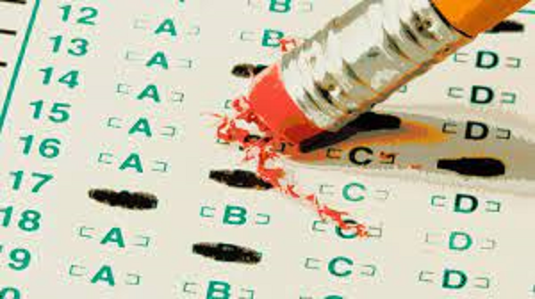

How widespread is the cheating?

The Gotham City public school system suspects that they may have a widespread cheating problem after two teachers were caught changing student test answers (modifying tests before turning them in) to improve their scores. Before implementing rules that may create friction with the teacher’s union, they decided to hire you to determine if the teacher driven cheating is wide-spread.

The school system tests students each year in grades 5-9 using the S.P.L.A.T. which is a 100 question test formatted as follows:

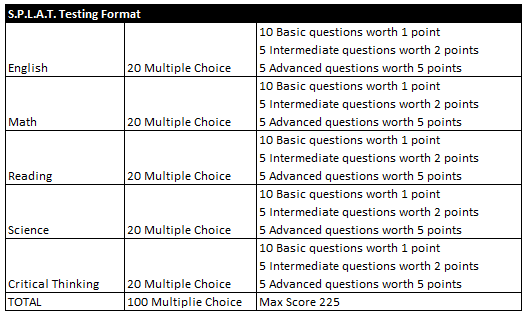

Each year there are about 300,000 tests given by about 10,000 teachers. They have given you detailed access to 10 years worth of testing data in electronic format so (that’s about 300 million questions and answers). You also have the usual meta-data like year, school, teacher and student for each test.

**Questions**

1. What do you think would be the best method to determine which teachers are likely to be cheaters?
   1. What steps will you take?
   2. What statistical methods or tools will you use?
2. There could be multiple methods, how might you combine a few of these to increase the accuracy of your answer?
3. How will you assign a confidence level to your conclusion that any given teacher is a cheater?